# R for Data Science

August 16, 2019

## Part I: Introduction

## Tidy Data

### When we have messy datasets, there are three interrelated rules which make a dataset tidy:

- 1. Each variable must have its own column.
- 2. Each observation must have its own row.
- 3. Each value must have its own cell.

### So follow this interrelationship lead us the correspond pratical instrucations.

## Package

### Here we focus on the `tidyr` package, another core member of the `tidyverse`, and we'll illustrate five tables, only the first one is tidy, show how to tidy the rest of four, which are the common messy examples.

```r
> library(tidyverse)
```

## Data

```r
> table1
# A tibble: 6 x 4
  country      year  cases population
  <chr>       <int>  <int>      <int>
1 Afghanistan  1999    745   19987071
2 Afghanistan  2000   2666   20595360
3 Brazil       1999  37737  172006362
4 Brazil       2000  80488  174504898
5 China        1999 212258 1272915272
6 China        2000 213766 1280428583
> table2
# A tibble: 12 x 4
   country      year type            count
   <chr>       <int> <chr>           <int>
 1 Afghanistan  1999 cases             745
 2 Afghanistan  1999 population   19987071
 3 Afghanistan  2000 cases            2666
 4 Afghanistan  2000 population   20595360
 5 Brazil       1999 cases           37737
 6 Brazil       1999 population  172006362
 7 Brazil       2000 cases           80488
 8 Brazil       2000 population  174504898
 9 China        1999 cases          212258
10 China        1999 population 1272915272
11 China        2000 cases          213766
12 China        2000 population 1280428583
```

## Functions

### We introduce kinds of functions to tidy data, like `gather`, `spread`, `separate`… in next several parts

## Part II: Work with tidy data

## `table1`

- `table1` is tidy, it's the only representation where each column is a variable.
- Commonly use `dplyr`, `ggplot2` in tidyverse to work with tidy data.

```r
> table1 %>%
+   mutate(rate = cases/population * 10000)
# A tibble: 6 x 5
  country      year  cases population  rate
  <chr>       <int>  <int>      <int> <dbl>
1 Afghanistan  1999    745   19987071 0.373
2 Afghanistan  2000   2666   20595360 1.29
3 Brazil       1999  37737  172006362 2.19
4 Brazil       2000  80488  174504898 4.61
5 China        1999 212258 1272915272 1.67
6 China        2000 213766 1280428583 1.67
```

## `table1`

### Compute cases per year

```r
> table1 %>%
+   count(year,wt=cases)
# A tibble: 2 x 2
   year      n
  <int>  <int>
1  1999 250740
2  2000 296920
```

## Visualize changes over time

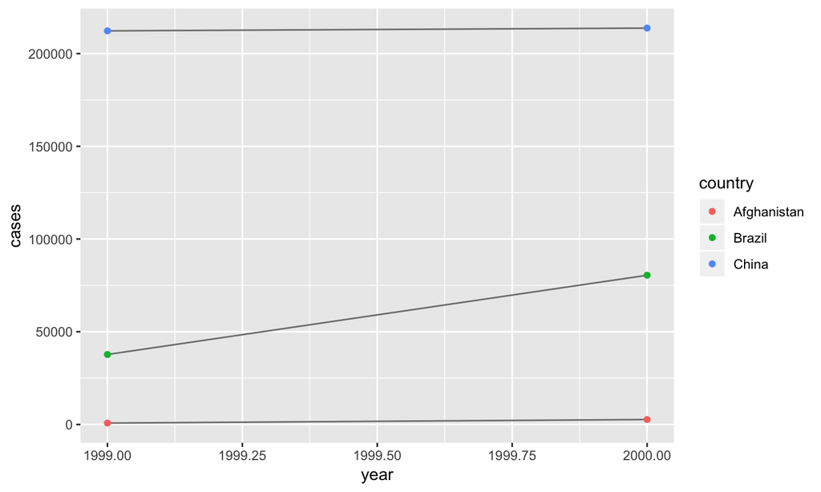

```r
> library(ggplot2)
> ggplot(table1, aes(year, cases)) +
+   geom_line(aes(group = country), color = "grey50") +
+   geom_point(aes(color = country))
```

## Part III: Spreading and Gathering

## `gather`

- A common problem is a dataset where some of the column names are not names of variables, but value of a variable.
- To tidy a dataset like `table4a` and `table4b`, we need to gather those columns into a new pair of variables.

```r
> table4a
# A tibble: 3 x 3
  country     `1999` `2000`
* <chr>        <int>  <int>
1 Afghanistan    745   2666
2 Brazil       37737  80488
3 China       212258 213766
> table4b
# A tibble: 3 x 3
  country         `1999`     `2000`
* <chr>            <int>      <int>
1 Afghanistan   19987071   20595360
2 Brazil       172006362  174504898
3 China       1272915272 1280428583
```

## key and value

- The name of the variable whose values form the column names is called the key, and here it is year.
- The name of the variable whose values are spread over the cells is called the value, and here it is the number of cases and population.

```r
> (tidy4a<-table4a %>%
+   gather(`1999`,`2000`, key = "year", value = "cases"))
# A tibble: 6 x 3
  country     year   cases
  <chr>       <chr>  <int>
1 Afghanistan 1999     745
2 Brazil      1999   37737
3 China       1999  212258
4 Afghanistan 2000    2666
5 Brazil      2000   80488
6 China       2000  213766
> tidy4b<-table4b %>%
+   gather(`1999`,`2000`, key = "year", value = "population")
```

## `left_join`

- Combine the tidied versions of table4a and table4b into a single tibble, use `left_join` function.

```r
> left_join(tidy4a, tidy4b)
Joining, by = c("country", "year")
# A tibble: 6 x 4
  country     year   cases population
  <chr>       <chr>  <int>      <int>
1 Afghanistan 1999     745   19987071
2 Brazil      1999   37737  172006362
3 China       1999  212258 1272915272
4 Afghanistan 2000    2666   20595360
5 Brazil      2000   80488  174504898
6 China       2000  213766 1280428583
```

## `spread`

- When an observation is scattered acorss multiple rows, we use spread.
- The column that contains variable names, the key column, here it's type.
- The column that contains values forms multiple variables, the value column, here it's count

```r
> table2
# A tibble: 12 x 4
   country      year type            count
   <chr>       <int> <chr>           <int>
 1 Afghanistan  1999 cases             745
 2 Afghanistan  1999 population   19987071
 3 Afghanistan  2000 cases            2666
 4 Afghanistan  2000 population   20595360
 5 Brazil       1999 cases           37737
 6 Brazil       1999 population  172006362
 7 Brazil       2000 cases           80488
 8 Brazil       2000 population  174504898
 9 China        1999 cases          212258
10 China        1999 population 1272915272
11 China        2000 cases          213766
12 China        2000 population 1280428583
```

## `spread`

```r
> spread(table2, key = type, value = count)
# A tibble: 6 x 4
  country      year  cases population
  <chr>       <int>  <int>      <int>
1 Afghanistan  1999    745   19987071
2 Afghanistan  2000   2666   20595360
3 Brazil       1999  37737  172006362
4 Brazil       2000  80488  174504898
5 China        1999 212258 1272915272
6 China        2000 213766 1280428583
```

## Part IV: Separating and Pull

## `separate`

- separate() pulls apart one column into multiple columns, by spliting wherever a separator character appears.

```r
> table3
# A tibble: 6 x 3
  country      year rate
* <chr>       <int> <chr>
1 Afghanistan  1999 745/19987071
2 Afghanistan  2000 2666/20595360
3 Brazil       1999 37737/172006362
4 Brazil       2000 80488/174504898
5 China        1999 212258/1272915272
6 China        2000 213766/1280428583
> table3 %>%
+   separate(rate, into = c("case","population"))
# A tibble: 6 x 4
  country      year case   population
  <chr>       <int> <chr>  <chr>
1 Afghanistan  1999 745    19987071
2 Afghanistan  2000 2666   20595360
3 Brazil       1999 37737  172006362
4 Brazil       2000 80488  174504898
5 China        1999 212258 1272915272
6 China        2000 213766 1280428583
```

## `separate`

- separate() will split values wherever it sees a nonalphanumeric character, and here we can rewrite the preceding code as:

```r
> table3 %>%
+   separate(rate, into = c("case","population"), seq = "/")
```

- But it leaves the type of the column as is, so try to convert to better types using convert = TRUE

```r
> table3 %>%
+   separate(rate, into = c("case","population"), convert = TRUE)
# A tibble: 6 x 4
  country      year   case population
  <chr>       <int>  <int>      <int>
1 Afghanistan  1999    745   19987071
2 Afghanistan  2000   2666   20595360
3 Brazil       1999  37737  172006362
4 Brazil       2000  80488  174504898
5 China        1999 212258 1272915272
6 China        2000 213766 1280428583
```

## `separate`

- And we can also interpret the integers as positions to split at.

```r
> table3 %>%
+   separate(year, into = c("case","population"), sep = 2)
# A tibble: 6 x 4
  country     case  population rate
  <chr>       <chr> <chr>      <chr>
1 Afghanistan 19    99         745/19987071
2 Afghanistan 20    00         2666/20595360
3 Brazil      19    99         37737/172006362
4 Brazil      20    00         80488/174504898
5 China       19    99         212258/1272915272
6 China       20    00         213766/1280428583
```

## `unite`

- unite() combines multiple columns into a single column

```r
> table5
# A tibble: 6 x 4
  country     century year  rate
* <chr>       <chr>   <chr> <chr>
1 Afghanistan 19      99    745/19987071
2 Afghanistan 20      00    2666/20595360
3 Brazil      19      99    37737/172006362
4 Brazil      20      00    80488/174504898
5 China       19      99    212258/1272915272
6 China       20      00    213766/1280428583
> table5 %>%
+   unite(new,century,year)
# A tibble: 6 x 3
  country     new   rate
  <chr>       <chr> <chr>
1 Afghanistan 19_99 745/19987071
2 Afghanistan 20_00 2666/20595360
3 Brazil      19_99 37737/172006362
4 Brazil      20_00 80488/174504898
5 China       19_99 212258/1272915272
6 China       20_00 213766/1280428583
```

## `unite`

- The default will place an underscore(_) between the values from different columns.

```r
> table5 %>%
+   unite(new,century,year, sep = "")
# A tibble: 6 x 3
  country     new   rate
  <chr>       <chr> <chr>
1 Afghanistan 1999  745/19987071
2 Afghanistan 2000  2666/20595360
3 Brazil      1999  37737/172006362
4 Brazil      2000  80488/174504898
5 China       1999  212258/1272915272
6 China       2000  213766/1280428583
```

## Exercises

- Here let's pull together everything to tackle a realistic data tidying problem. The `tidyr::who` dataset contains tuberculosis(TB) cases broken down by year, country, age, gender, and diagnosis method. There's a wealth of epidemiological information in this dataset, but it's challenging to work with the data in the form that it's provided:

```r
> who
# A tibble: 7,240 x 60
   country iso2  iso3   year new_sp_m014 new_sp_m1524 new_sp_m2534
   <chr>   <chr> <chr> <int>       <int>        <int>        <int>
 1 Afghan… AF    AFG    1980          NA           NA           NA
 2 Afghan… AF    AFG    1981          NA           NA           NA
 3 Afghan… AF    AFG    1982          NA           NA           NA
 4 Afghan… AF    AFG    1983          NA           NA           NA
 5 Afghan… AF    AFG    1984          NA           NA           NA
 6 Afghan… AF    AFG    1985          NA           NA           NA
 7 Afghan… AF    AFG    1986          NA           NA           NA
 8 Afghan… AF    AFG    1987          NA           NA           NA
 9 Afghan… AF    AFG    1988          NA           NA           NA
10 Afghan… AF    AFG    1989          NA           NA           NA
# … with 7,230 more rows, and 53 more variables: new_sp_m3544 <int>,
#   new_sp_m4554 <int>, new_sp_m5564 <int>, new_sp_m65 <int>,
#   new_sp_f014 <int>, new_sp_f1524 <int>, new_sp_f2534 <int>,
#   new_sp_f3544 <int>, new_sp_f4554 <int>, new_sp_f5564 <int>,
#   new_sp_f65 <int>, new_sn_m014 <int>, new_sn_m1524 <int>,
#   new_sn_m2534 <int>, new_sn_m3544 <int>, new_sn_m4554 <int>,
#   new_sn_m5564 <int>, new_sn_m65 <int>, new_sn_f014 <int>,
#   new_sn_f1524 <int>, new_sn_f2534 <int>, new_sn_f3544 <int>,
#   new_sn_f4554 <int>, new_sn_f5564 <int>, new_sn_f65 <int>,
#   new_ep_m014 <int>, new_ep_m1524 <int>, new_ep_m2534 <int>,
#   new_ep_m3544 <int>, new_ep_m4554 <int>, new_ep_m5564 <int>,
#   new_ep_m65 <int>, new_ep_f014 <int>, new_ep_f1524 <int>,
#   new_ep_f2534 <int>, new_ep_f3544 <int>, new_ep_f4554 <int>,
#   new_ep_f5564 <int>, new_ep_f65 <int>, newrel_m014 <int>,
#   newrel_m1524 <int>, newrel_m2534 <int>, newrel_m3544 <int>,
#   newrel_m4554 <int>, newrel_m5564 <int>, newrel_m65 <int>,
#   newrel_f014 <int>, newrel_f1524 <int>, newrel_f2534 <int>,
#   newrel_f3544 <int>, newrel_f4554 <int>, newrel_f5564 <int>,
#   newrel_f65 <int>
```

## Exercises

### Now follow the instructions to tidy the data:

- The country, iso2, iso3 are three variables that redundantly specify the country.
- Make a minor fix to the format of the column names replace the characters "newrel" with "new_rel"
- The variable names(e.g., new_sp_m014, new_ep_m014, new_ep_f014) these are likely to be values, not variables.
- For one of these varibale names, the first three letters of each column denote whether the column contains new or old cases of TB.In this datasetm each column contains new cases.
- The next two letters describe the type of TB.
- The sixth letter gives the sex of TB patients. The dataset groups cases by males(m) and females(f).
- The remaining numbers give the age group(e.g., 014=0-14 years old,1524=15-24 years old,65=65 or older)

## Solution

```r
> who %>%
+   gather(code, value, new_sp_m014:newrel_f65, na.rm = TRUE) %>%
+   mutate(
+     code = stringr::str_replace(code, "newrel", "new_rel")
+   ) %>%
+   separate(code, c("new","var","sexage")) %>%
+   select(-new,-iso2,-iso3) %>%
+   separate(sexage, c("sex", "age"), sep = 1)
# A tibble: 76,046 x 6
   country      year var   sex   age   value
   <chr>       <int> <chr> <chr> <chr> <int>
 1 Afghanistan  1997 sp    m     014       0
 2 Afghanistan  1998 sp    m     014      30
 3 Afghanistan  1999 sp    m     014       8
 4 Afghanistan  2000 sp    m     014      52
 5 Afghanistan  2001 sp    m     014     129
 6 Afghanistan  2002 sp    m     014      90
 7 Afghanistan  2003 sp    m     014     127
 8 Afghanistan  2004 sp    m     014     139
 9 Afghanistan  2005 sp    m     014     151
10 Afghanistan  2006 sp    m     014     193
# … with 76,036 more rows
```

## Part V: Brainstorm

## `gather()`

```r
> table4a %>%
+   gather('1999','2000', key = "year", value = "cases")
# A tibble: 6 x 3
  country     year   cases
  <chr>       <chr>  <int>
1 Afghanistan 1999     745
2 Brazil      1999   37737
3 China       1999  212258
4 Afghanistan 2000    2666
5 Brazil      2000   80488
6 China       2000  213766
```

## `gather()`

```r
> table4a %>%
+   gather(year,cases,-country)
# A tibble: 6 x 3
  country     year   cases
  <chr>       <chr>  <int>
1 Afghanistan 1999     745
2 Brazil      1999   37737
3 China       1999  212258
4 Afghanistan 2000    2666
5 Brazil      2000   80488
6 China       2000  213766
```

## `gather()`

```r
> table4a %>%
+   gather("year", "cases",'1999':'2000')
# A tibble: 6 x 3
  country     year   cases
  <chr>       <chr>  <int>
1 Afghanistan 1999     745
2 Brazil      1999   37737
3 China       1999  212258
4 Afghanistan 2000    2666
5 Brazil      2000   80488
6 China       2000  213766
```